# Лабораторная Работа №10

Настройка списков управления доступом (ACL)

Козлов В.П.

Российский университет дружбы народов им. Патриса Лумумбы, Москва, Россия

## Докладчик

- Козлов Всеволод Павлович
- НФИбд-02-22
- Российский университет дружбы народов
- [1132226428@pfur.ru]

# Выполнение лабораторной работы

## Цель работы

Освоить настройку прав доступа пользователей к ресурсам сети

## Задание

1. Требуется настроить следующие правила доступа:
1. web-сервер: разрешить доступ всем пользователям по протоколу HTTP через порт 80 протокола TCP, а для администратора открыть доступ по протоколам Telnet и FTP;
2. файловый сервер: с внутренних адресов сети доступ открыт по портам для общедоступных каталогов, с внешних — доступ по протоколу FTP;
3. почтовый сервер: разрешить пользователям работать по протоколам SMTP и POP3 (соответственно через порты 25 и 110 протокола TCP), а для администратора — открыть доступ по протоколам Telnet и FTP;
4. DNS-сервер: открыть порт 53 протокола UDP для доступа из внутренней сети;
5. разрешить icmp-сообщения, направленные в сеть серверов;
6. запретить для сети Other любые запросы за пределы сети, за исключением администратора;
7. разрешить доступ в сеть управления сетевым оборудованием только администратору сети.
2. Требуется проверить правильность действия установленных правил доступа.
3. Требуется выполнить задание для самостоятельной работы по настройке прав доступа администратора сети на Павловской.
4. При выполнении работы необходимо учитывать соглашение об именовании.

## Подключил ноутбук администратора

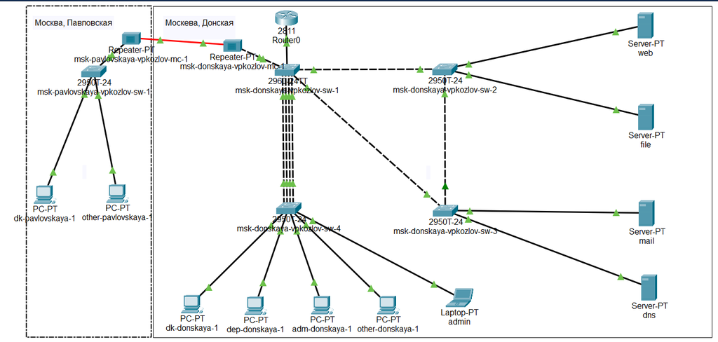

Ноутбук администратора

## Настроил конфигурацию ноутбука администратора

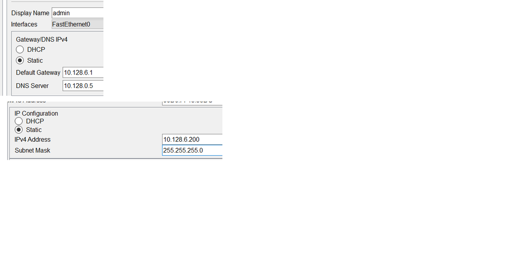

Конфигурация ноутбука администратора

## Проверка работоспособности соединения ноутбука admin

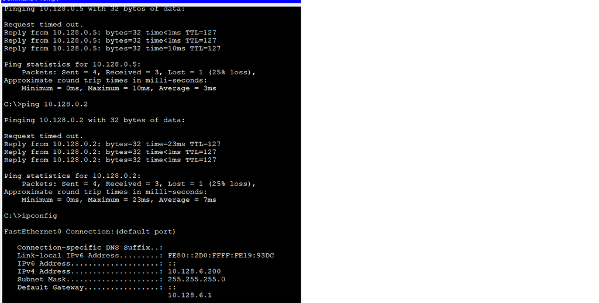

Проверка работоспособности соединения ноутбука admin

## Настройка доступа к web-серверу по порту tcp 80

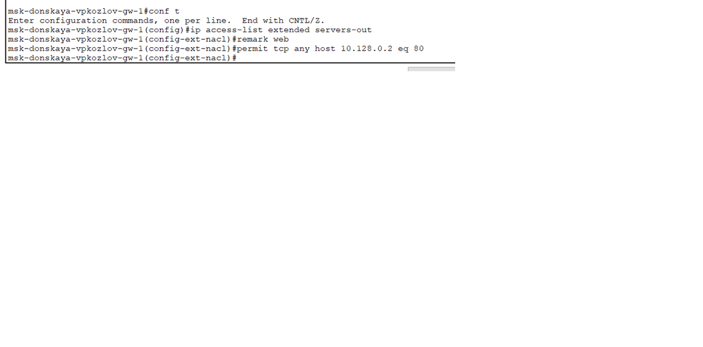

Настройка доступа к web-серверу по порту tcp 80

## Добавление списка управления доступом к интерфейсу

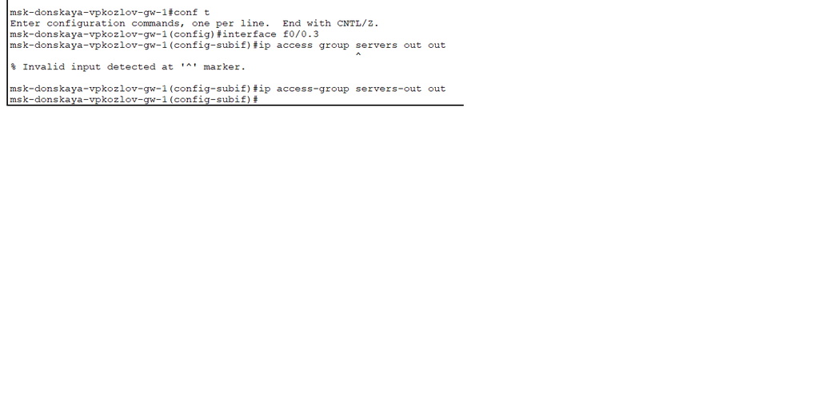

Добавление списка управления доступом к интерфейсу

## Проверка недоступности web-сервера через ping

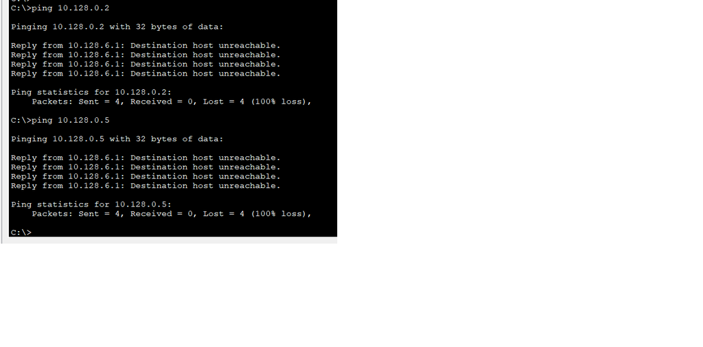

Недоступность web-сервера через ping

## Дополнительный доступ для администратора по протоколам Telnet и FTP

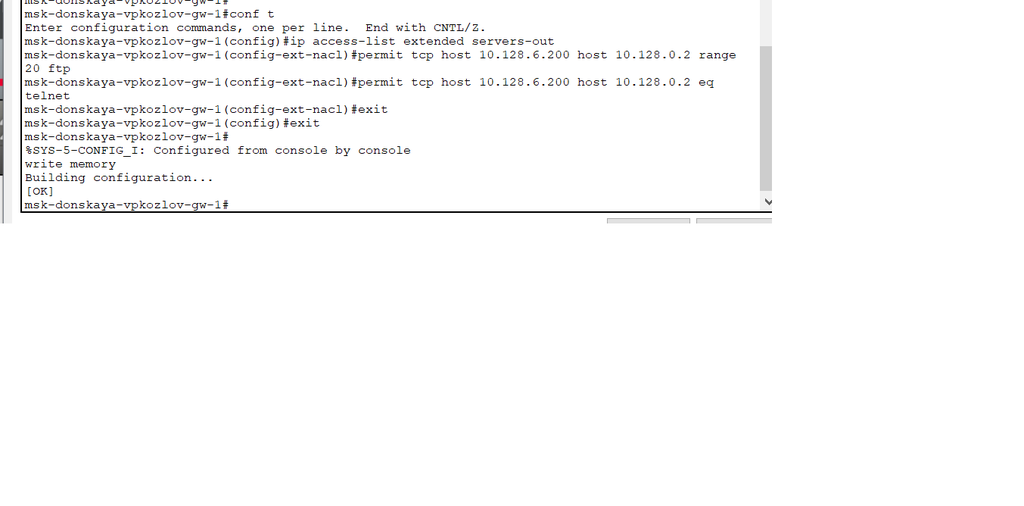

Дополнительный доступ для администратора по протоколам Telnet и FTP

## Попытка подключения по FTP

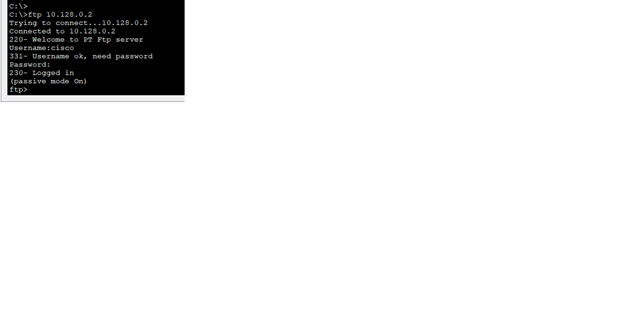

Попытка подключения по FTP

## Настройка доступа к файловому серверу

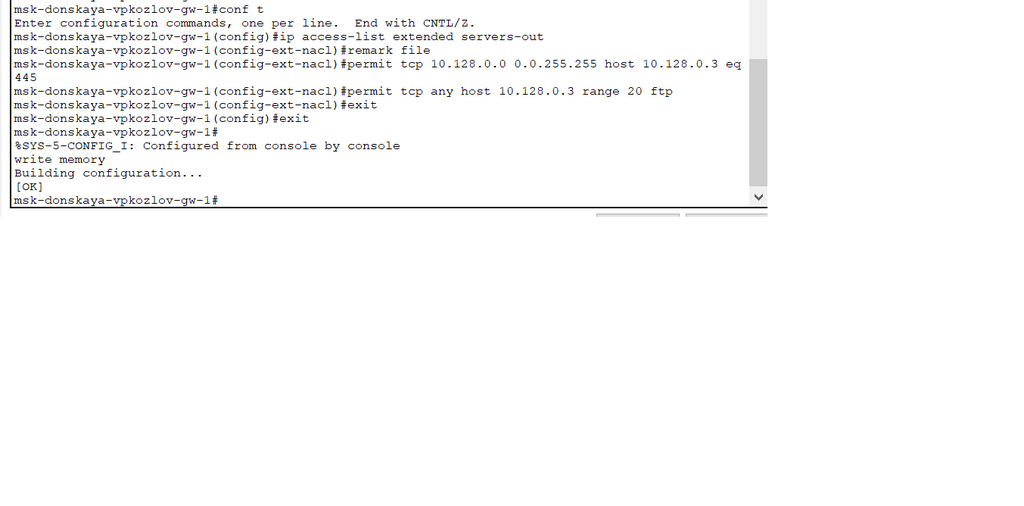

Настройка доступа к файловому серверу

## Настройка доступа к почтовому серверу

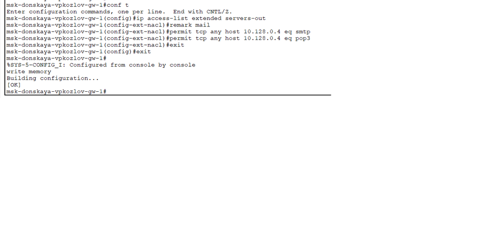

Настройка доступа к почтовому серверу

## Настройка доступа к DNS-серверу

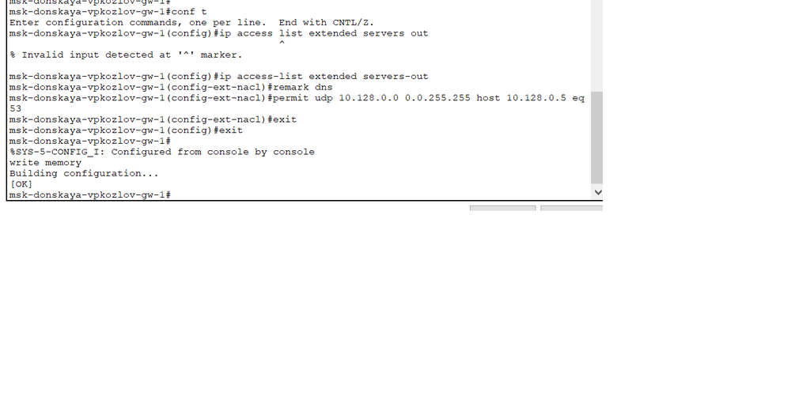

Настройка доступа к DNS-серверу

## Проверил доступность web-сервера в браузере

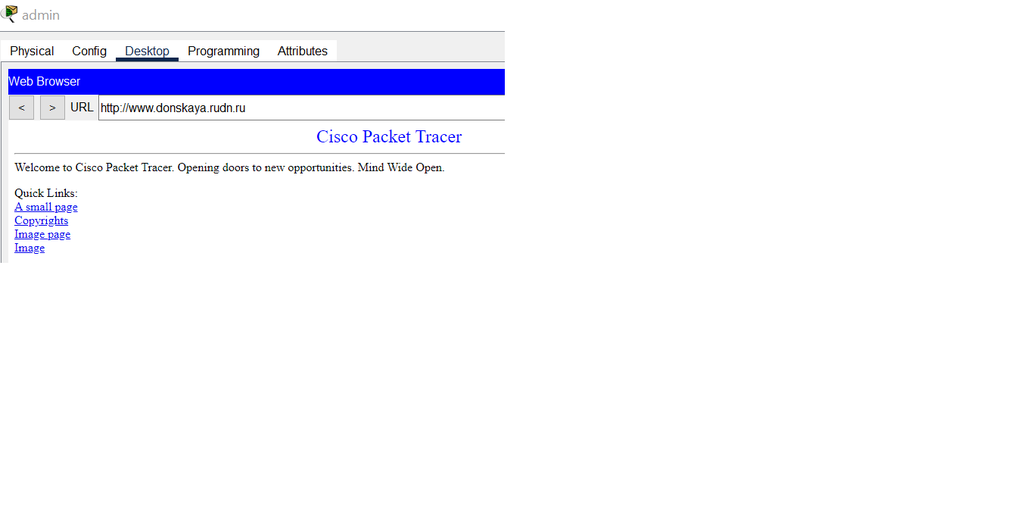

Доступность web-сервера в браузере

## Разрешение icmp-запросов

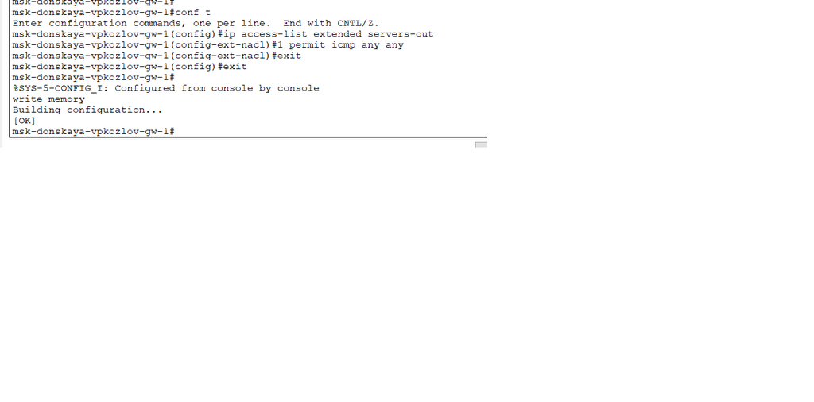

Разрешение icmp-запросов

## Посмотрел правила в списке контроля доступа

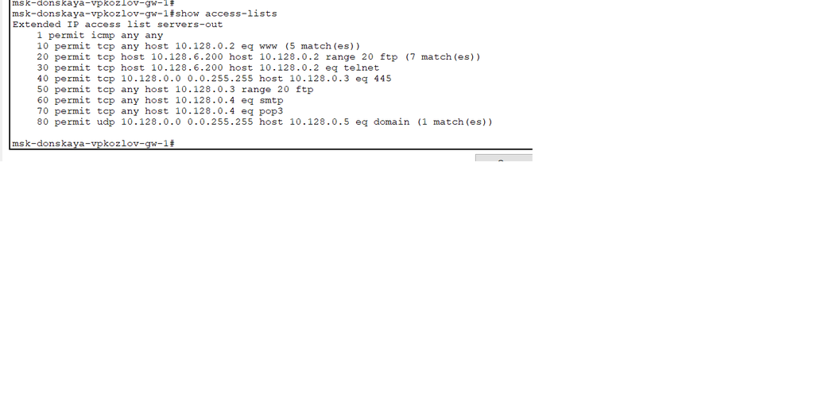

Правила в списке контроля доступа

## Проверил пингование

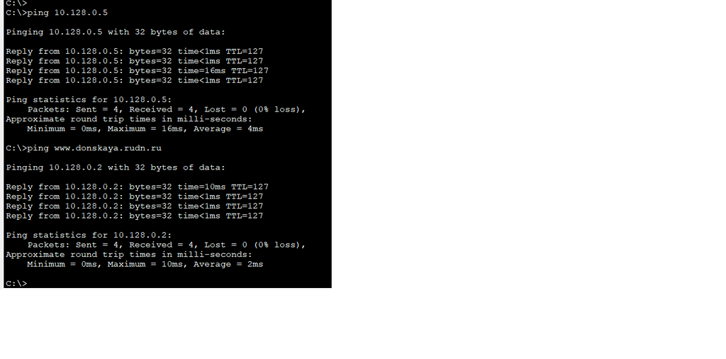

Проверка пингования

## Настройка доступа для сети Other

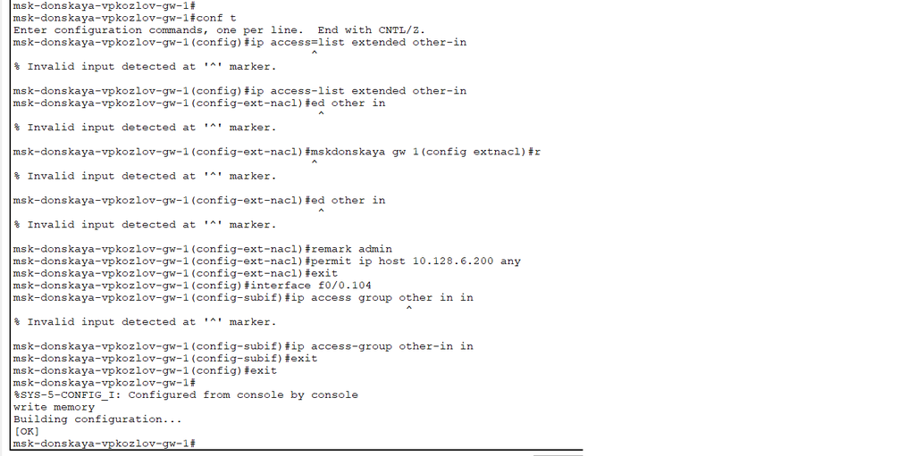

Настройка доступа для сети Other

# Самостоятельная работа

## Пингование с устройства dep-donskaya-vpkozlov-1

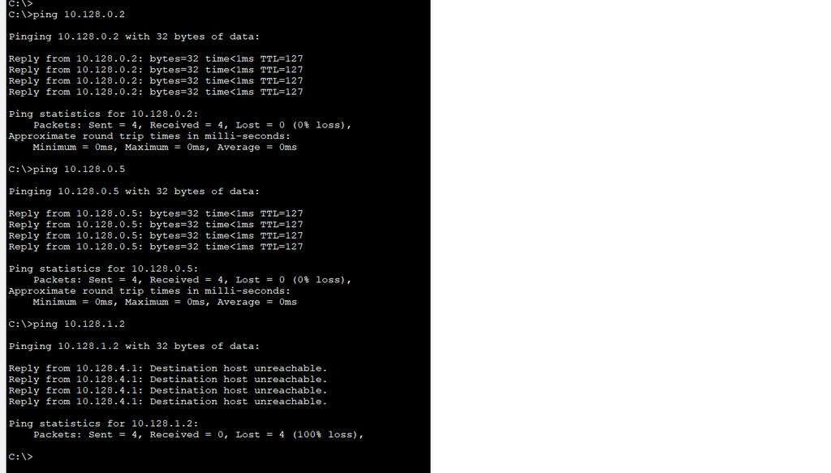

Пингование с устройства dep-donskaya-vpkozlov-1

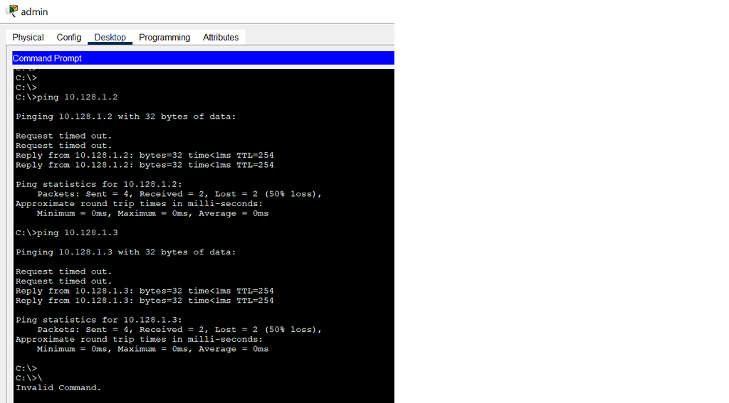

## Размещение ноутбука admin на Павловской

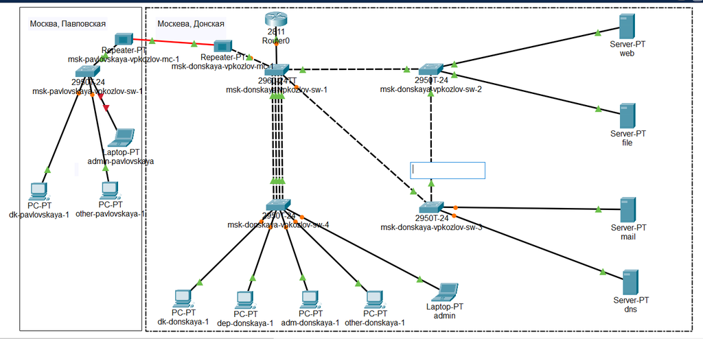

Размещение ноутбука admin на Павловской

## Настройка доступа для admin-pavlovskaya

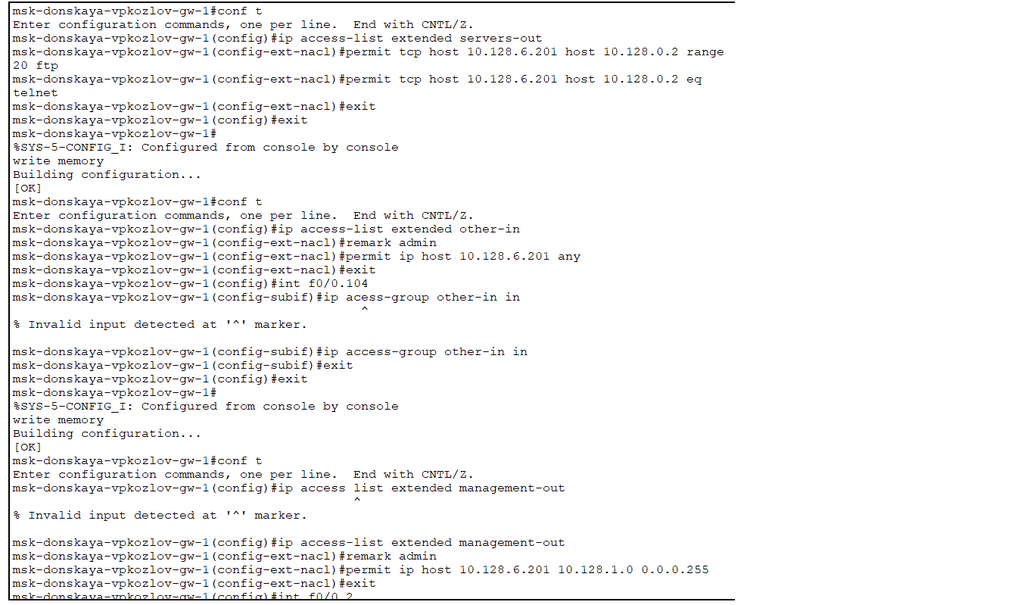

Настройка доступа для admin-pavlovskaya

## Список контроля доступа

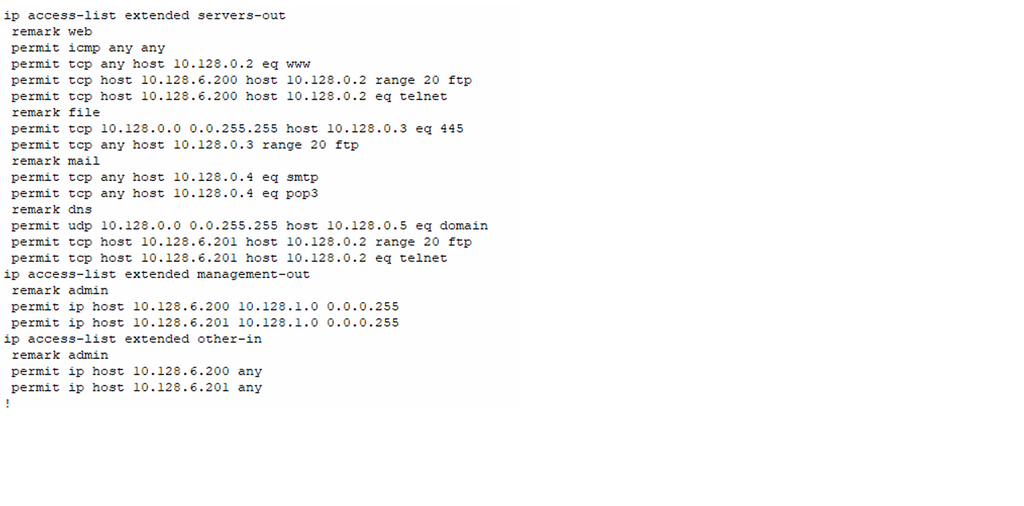

Список контроля доступа

## Проверка корректности настроенного доступа

[figure not shown]

Проверка корректности настроенного доступа

## Выводы

Освоил настройку прав доступа пользователей к ресурсам сети